# R Notebook

## Author: OA Lab, NWFSC

### Title: Aquarium Temperature Investigation: Temperature SubSelectScript.R

### Date: April-May 2020

# Aquarium Temperature Investigation

R script below will subselect and plot temperature data for MOATs Overall goal is to determine if MOATs (per treatment) are true replicates

```r
#*********************************
##Libraries
#*********************************
library(shiny)
library(tidyverse)
library(stringr)
library(readxl)
library(readr)
library(tidyr)
library(data.table)
library(lubridate)
library(violinmplot)
library(vioplot)
library(yarrr)
library(datapasta)
library(reprex)
library(miniUI)
library(gridExtra)
```

## Outline

(Current as of 2020.06.25)

- 1.) Working Directory
- 2.) Spolling Data into one CSV
- 3.) Creating the Dataframe “dml”
- 4.) Setting a new working directory
- 4.) Creating dateTime objects
- 5.) Creating Treatment Variables
- 6.) Creating Night and Day Periods
- 7.) Insitu data
- 8.) Cleaning up dml “Cdml”
- 9.) Framing filters for Cdml
- 10.) Temperature “Jumps”
- 11.) Calculating averages by treatment & day/night
- 12.) Summary & Group by Cdml
- 13.) Plots Boxplots & timeseries
- 14.) Duration between conditions- Histogram & Cummulative Distribtuion Plot section
- 15.) aTemp bands investig.
- 16.) Share-able tibbles & reprex readiness

#1.) Working Directory

Inside the working directory (folder) are CSV files generated after using the moats graph app [Link to moats.Graph.app](http://github.com/pmcelhany/moatsGraphs.git) Moving average window (nObs) set to 4. This results in the observations being averaged into a 24second timeframe. CSVs were created for each moats: M01, M02, M03, M04, M05, M06, M07, M08, M09, M10, M11, M12, M13. Files are also available on the OA Google drive. [OA Drive for MOATS data](https://drive.google.com/open?id=13a2hk1a9I9gRIgf2Xyl1dSYDf5vnyYvs)

# 2.) Spolling Data into one CSV

Combining multiple CSV files into 1 document. Original input files from individual LVM (logical volumne management) files off each MOATs. 2.1 Create a list of files

```r
## 2.1 Create a list of files
# All files to be joined have ext. "csv" can use that pattern to join
files <- list.files(path= "/Users/katherinerovinski/GIT/NWFSC.MUK_MOATs_SMR2019/LabViewLogs(CSV)Rbind", pattern = ".*\\.csv")
print(files)
```

```
 [1] "M1_df_MoatsData.csv"  "M10_df_MoatsData.csv" "M11_df_MoatsData.csv"
 [4] "M12_df_MoatsData.csv" "M13_df_MoatsData.csv" "M2_df_MoatsData.csv"
 [7] "M3_df_MoatsData.csv"  "M4_df_MoatsData.csv"  "M5_df_MoatsData.csv"
[10] "M6_df_MoatsData.csv"  "M7_df_MoatsData.csv"  "M8_df_MoatsData.csv"
[13] "M9_df_MoatsData.csv"
```

2.2 Create a temporary place for files

```r
## 2.2 Create a temporary place for files
temp <- lapply(files, fread, sep= ",")
```

[output not shown]

2.3 Create a new vector for Moats data logs

```r
## 2.5 Write the new csv document |
# "M01thruM13moatslog" can uncomment this command line as needed
#write.csv(M01thruM13moatslog_data, file = "M01thruM13moatslog.csv", row.names = FALSE)
```

Saved on the OA Google Drive [M01thruM13moatslog.csv](https://drive.google.com/open?id=15iBXct9b4EjKDq75vKnm5NobowBwK3G-)

# 3.) Creating the Dataframe “dml”

3.1 Reading the CSV

```r
## 3.1 Reading the CSV |
## ensuring column names and types
## Data Moats Log = dml
dml <- read.csv( file = "M01thruM13moatslog.csv", stringsAsFactors = FALSE)
dim(dml)
```

3.1a Duplication Check

```r
## 3.1a Duplication Check
## duplicates observed in "dml" on 2020.05.07
dup2 <- dml[duplicated(dml),]
#if no dups, Cdml2 has same number of rows as Cdml
dml2 <- dml %>% distinct()
```

3.1b Sub sampling dataframe “dml”

```r
## 3.1b Sub sampling dataframe "dml"
## creating a sub sample of the data moats log dml dataframe to allow for quick graphs


#subsample every 17th row (because prime numbers are indeed cool)
dml <- dml %>% arrange(moats, dateTime) %>% filter(row_number() %% 17 == 0)

#write.csv(dml, file = "M01thruM13moatslog_n17.csv", row.names = FALSE)
```

3.2 Checking variables

```r
## 3.2 Checking variables
## Looking to ensure the different variables are treated as the correct variable type
## Checking the names in the dataframe
names(dml)
## Checking variable type/class
class(dml$moats)
dml$moats <- as.factor(dml$moats)
```

3.3 Changing variables

```r
## 3.3 Changing variables |
## Changing MOATs to Factors for the 13 different MOATs- these will be the discrete units for follow analysis
dml$moats <- factor(dml$moats)
# Checking the names of the different levels
levels(dml$moats)
##checking the dataset, dimensions
dim(dml)
```

#4.) Creating dateTime objects

4.0 Establish the dateTime objects

```r
# 4.0 establish the date time object of the CSV |
dml$dateTime <- as.POSIXct(dml$dateTime, format="%Y-%m-%d %H:%M:%OS")
ReferenceTime <- as.POSIXct("2019-09-20 23:59:00")
class(ReferenceTime)

# QA check
dim(dml)
```

# 5.) Creating Treatment Variables

5.1 Identifying Treatments by MOATS

```r
## 5.1 Identifying treatments by moats
## establishing treatments
dml$treatment <- ""
dml$treatment[dml$moats == "M07" | dml$moats== "M10" | dml$moats== "M12"] <- "current"
dml$treatment[dml$moats == "M01"| dml$moats== "M06"] <- "hightemperature"
dml$treatment[dml$moats == "M02"| dml$moats== "M08" | dml$moats== "M13"] <- "allchange"
dml$treatment[dml$moats == "M03"| dml$moats == "M04" | dml$moats == "M05" | dml$moats== "M11"] <- "broken_and_ambientbroken"
#verify that this new column has been created
names(dml)
#results should include:
#[1] "moats"        "dateTime"     "aTemperature" "sTemperature" "pH"
#[6] "DO"           "salinity"     "treatment"

# QA check
dim(dml)
```

5.2 Simple ggplot to show the different MOATs without polish

```r
plot5.2 <- ggplot(dml, aes(x=dateTime, y=aTemperature)) +
  geom_point(aes(colour=moats, point=)) +
  ggtitle("All MOATs, All Treatment aTemperature Time Series")

plot5.2
```

[figure not shown]

# 6.) Creating Night and Day Periods

6.1 Narrative (Overall) Creating a day and night variables Day and night periods exclude the acclimation period by their definition. Day and night changed at about ~ 1230 on 05OCT19 Treatment start date considered to begin Monday 23SEP19 at 1200pm

Krill Night Started 1200 (~1230*) and ends 2100 Krill Days Started 2101 and ends 1159 (~1229*)

#### Interval 1 start 1200 23SEP19, end 1229 05OCT19

#### Interval 2 start 1230 05OCT19, end 2100 30OCT19

# Concept Diagram graphic

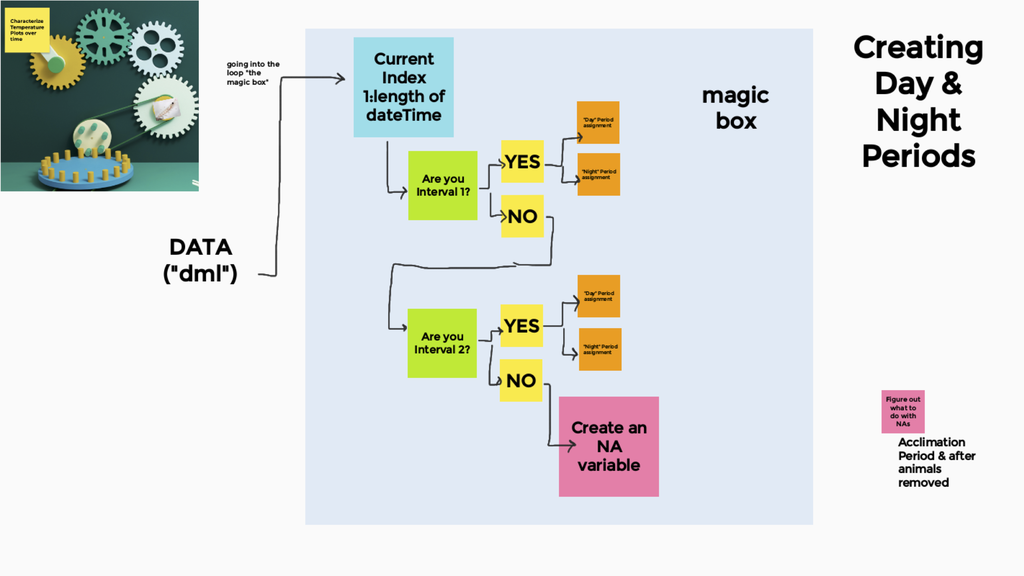

Day/Night Definitions Concept Diagram Figure2

6.2 New Column, New Variable

```r
## 6.2 New Column, New Variable in dml
#creating a new column, new variable "period"
dml$period <- ""
```

6.3 Disassembling dateTime to create 2 new variables

```r
## 6.3 Disassembling dateTime to create 2 new variables
# Create new split date and time columns
dml$ObservationDate <- as.Date(dml$dateTime)
dml$ObservationTime <- format(as.POSIXct(dml$dateTime) ,format = "%H:%M:%S")
```

### Interval 2

```r
#*********************************
## 1.) Set working directory
#*********************************
knitr::opts_chunk$set(echo = TRUE)

knitr::opts_knit$set(root.dir = "/Users/katherinerovinski/GIT/NWFSC.MUK_KRL_SMR2019/06. MOATS replication verification")
```

# 7.) Insitu data

7.0 In-situ data files Two files represent manual checks of aquarium salinity. Extracted from this are point measurements of aquarim temperature

```r
# ## 7.1 Read in files
# # carefule about navigating to the second working directory
#
#
# knitr::opts_chunk$set(echo = TRUE)
# knitr::opts_knit$set(root.dir = "/Users/katherinerovinski/GIT/NWFSC.MUK_KRL_SMR2019/06. MOATS replication verification/01. Raw Data/InSituSampling")
#
#
# d.insitu <- read.csv(file = "KRL19_insitu_sample_Day.csv", stringsAsFactors = FALSE)
# n.insitu <- read.csv(file = "KRL19_insitu_sample_Night.csv", stringsAsFactors = FALSE)
```

# 8.) Cleaning up dml

Creating a new dataframe cleaned with the various filters below checking on the variables inside dml Cleaned-Up dml = Cdml

```r
## 8.1 Noting names of the different variables in dml
names(dml)
```

# 8.2 Narrative on desired changes to create Cdml

8.2 Narrative on Cdml Temperatures below 5C and above 30C are thought to be less than probable

```r
# Changes to be made the dataframe by variable
#[1] "moats" "M03", "M04", "M05", "M09", "M11" to be filtered out- all these
#                                           MOATs were dropped from the study
#[2] "dateTime" - no changes
#[3] "aTemperature" - no changes
#[4] "sTemperature" - no changes
#[5] "pH" - no changes
#[6] "DO"- no changes
#[7] "salinity" - no changes
#[8] "treatment" - dropping the listed MOATs will eliminate the
#                           "broken_and_ambientbroken" treatment
#[9] "period" - filtering out "other"
#[10] "ObservationDate" - no changes
#[11] "ObservationTime" - no changes, note that each observation could be
#                                                 spaced 6.8minutes apart

Cdml <- dml %>% filter(!moats %in% c("M03", "M04", "M05", "M11")) %>%
  filter(aTemperature>= 5 & aTemperature<=30) %>%
  filter(treatment %in% c("current", "allchange", "hightemperature")) %>%
  filter(period != "other")
```

# 8.3 Option to write a CSV of Cdml parameters

droping the levels of the moats

```r
levels(Cdml$moats)
Cdml$moats <- droplevels(Cdml$moats)
```

# 9.) Framing filters for Cdml

9.0 cleaning names of levels, factors

```r
## 9.0 Removing the names of moats & treatments removed from Cdml
# Removal should allow for cleaner graphs
# Determined moats lab never got under 5C and was never over 30C

filteredFrame = filter(Cdml,
  !moats %in% c('M03', "M04", "M05", "M11") &
  (aTemperature>= 5 & aTemperature<=30) &
  treatment %in% c("current", "allchange", "hightemperature") &
  period != "other")
```

Without dropping levels and factors not named label may still crowd plots 9.1 Dropping names and factors

```r
## 9.1 Dropping levels and factors
filteredFrame$moats <- droplevels(filteredFrame$moats)
filteredFrame$treatment <- factor(filteredFrame$treatment)
```

9.2 Broad-gague test of plots by treatment

#### 9.2.1 All Change Day Period Boxplot

```r
simpleplot_allchg_day <- ggplot(subset(Cdml[Cdml$treatment == "allchange", ],
                                          period %in% ("day")),
                                          aes(x=moats, y=aTemperature,
                                                        colour=treatment)) +
                                          stat_summary(fun=mean, geom="point",
                                                        size=2, color="red")  +
                                          geom_boxplot() +
                                          ggtitle("All Change Treatment, Aquarium Temperature,Day Period Boxplot")


simpleplot_allchg_day
```

[output not shown]

#### 9.2.2 All Change Night Period Boxplot

```r
simpleplot_allchg_night <- ggplot(subset(Cdml[Cdml$treatment == "allchange", ],
                                          period %in% ("night")),
                                          aes(x=moats, y=aTemperature,
                                                        colour=treatment)) +
                                          stat_summary(fun=mean, geom="point",
                                                        size=2, color="red")  +
                                          geom_boxplot() +
                                          ggtitle("All Change Treatment, Aquarium Temperature, Night Period Boxplot")

simpleplot_allchg_night
```

[output not shown]

#### 9.2.3 All Change Timeseries

```r
simpleplot_allchg_timeseries <- ggplot(subset(Cdml[Cdml$treatment == "allchange", ]))+
                                  aes(x=dateTime, y=aTemperature) +
                                  geom_point(aes(colour=moats, point=)) +
                                  ggtitle("All Change Treatment, Aquarium Temperature, Timeseries")

simpleplot_allchg_timeseries
```

[output not shown]

#### 9.2.4 Current Day Period Boxplot

```r
simpleplot_cur_day <- ggplot(subset(Cdml[Cdml$treatment == "current", ],
                                          period %in% ("day")),
                                          aes(x=moats, y=aTemperature,
                                                        colour=treatment)) +
                                          stat_summary(fun=mean, geom="point",
                                                        size=2, color="red")  +
                                          geom_boxplot() +
                                          ggtitle("Current Conditions Treatment, Aquarium Temperature, Day Period Boxplot")


simpleplot_cur_day
```

[output not shown]

#### 9.2.5 Current Night Period Boxplot

```r
simpleplot_cur_night <- ggplot(subset(Cdml[Cdml$treatment == "current", ],
                                          period %in% ("night")),
                                          aes(x=moats, y=aTemperature,
                                                        colour=treatment)) +
                                          stat_summary(fun=mean, geom="point",
                                                        size=2, color="red")  +
                                          geom_boxplot() +
                                          ggtitle("Current Conditions Treatment, Aquarium Temperature, Night Period Boxplot")


simpleplot_cur_night
```

[output not shown]

#### 9.2.6 Current Conditions Timeseries

```r
simpleplot_cur_timeseries <- ggplot(subset(Cdml[Cdml$treatment == "current", ]))+
                                  aes(x=dateTime, y=aTemperature) +
                                  geom_point(aes(colour=moats, point=)) +
                                  ggtitle("Current Conditions Treatment, Aquarium Temperature, Timeseries")

simpleplot_cur_timeseries
```

[output not shown]

#### 9.2.7 High Temperature Day Period Boxplot

```r
simpleplot_hitemp_day <- ggplot(subset(Cdml[Cdml$treatment == "hightemperature", ],
                                          period %in% ("day")),
                                          aes(x=moats, y=aTemperature,
                                                        colour=treatment)) +
                                          stat_summary(fun=mean, geom="point",
                                                        size=2, color="red")  +
                                          geom_boxplot() +
                                          ggtitle("High Temperature, Aquarium Temperature, Conditions Day Period Boxplot")


simpleplot_hitemp_day
```

[output not shown]

#### 9.2.8 High Temperature Night Period Boxplot

```r
simpleplot_hitemp_night <- ggplot(subset(Cdml[Cdml$treatment == "hightemperature", ],
                                          period %in% ("night")),
                                          aes(x=moats, y=aTemperature,
                                                        colour=treatment)) +
                                          stat_summary(fun=mean, geom="point",
                                                        size=2, color="red")  +
                                          geom_boxplot() +
                                          ggtitle("High Temperature Conditions, Aquarium Temperature, Night Period Boxplot")


simpleplot_hitemp_night
```

[output not shown]

```r
simpleplot_cur_timeseries <- ggplot(subset(Cdml[Cdml$treatment == "current", ]))+
                                  aes(x=dateTime, y=aTemperature) +
                                  geom_point(aes(colour=moats, point=)) +
                                  ggtitle("Current Conditions Aquarium Temperature Treatment Timeseries")

simpleplot_cur_timeseries
```

[output not shown]